# A0248812B_HuangPingMao_Tut2

## import the library we need.

```python
import numpy as np
import pandas as pd
import matplotlib.pyplot as plt
import seaborn as sns
```

## read csv file.

```python
athlete_events = pd.read_csv('athlete_events.csv', delimiter=',')
noc_regions = pd.read_csv('noc_regions.csv', delimiter=',')
```

## check the data

```python
athlete_events.head()
```

|  | ID | Name | Sex | Age | Height | Weight | Team | NOC | Games | Year | Season | City | Sport | Event | Medal |
| --- | --- | --- | --- | --- | --- | --- | --- | --- | --- | --- | --- | --- | --- | --- | --- |
| 0 | 1 | A Dijiang | M | 24.0 | 180.0 | 80.0 | China | CHN | 1992 Summer | 1992 | Summer | Barcelona | Basketball | Basketball Men's Basketball | NaN |
| 1 | 2 | A Lamusi | M | 23.0 | 170.0 | 60.0 | China | CHN | 2012 Summer | 2012 | Summer | London | Judo | Judo Men's Extra-Lightweight | NaN |
| 2 | 3 | Gunnar Nielsen Aaby | M | 24.0 | NaN | NaN | Denmark | DEN | 1920 Summer | 1920 | Summer | Antwerpen | Football | Football Men's Football | NaN |
| 3 | 4 | Edgar Lindenau Aabye | M | 34.0 | NaN | NaN | Denmark/Sweden | DEN | 1900 Summer | 1900 | Summer | Paris | Tug-Of-War | Tug-Of-War Men's Tug-Of-War | Gold |
| 4 | 5 | Christine Jacoba Aaftink | F | 21.0 | 185.0 | 82.0 | Netherlands | NED | 1988 Winter | 1988 | Winter | Calgary | Speed Skating | Speed Skating Women's 500 metres | NaN |

```python
noc_regions.head()
```

|  | NOC | region | notes |
| --- | --- | --- | --- |
| 0 | AFG | Afghanistan | NaN |
| 1 | AHO | Curacao | Netherlands Antilles |
| 2 | ALB | Albania | NaN |
| 3 | ALG | Algeria | NaN |
| 4 | AND | Andorra | NaN |

# (a) What are the top three favourite sports of yours?

```python
print(sorted(athlete_events['Sport'].unique().tolist()))
```

[output not shown]

My top three favourite sports are the baseball, the basketball, and the table tennis.

# (b) What are the top three questions you want to ask regarding the data related to at least one of these three sports?

- (i) Which countries get the top three points in basketball for the whole time if gold medal for three points, silver medal for two points, and bronze medal for one point?
- (ii) Which country gets the longest winning streak in baseball? That is, Which country wins the longest in a row with the top three in baseball?
- (iii) What is the probability to get other medals when winning one medal?

# (c) Using Pandas and Seaborn, analyze and visualize the data to help answer your three questions raised in Step (b) above.

## (i) Which countries get the top three points in basketball for the whole time if gold medal for three points, silver medal for two points, and bronze medal for one point?

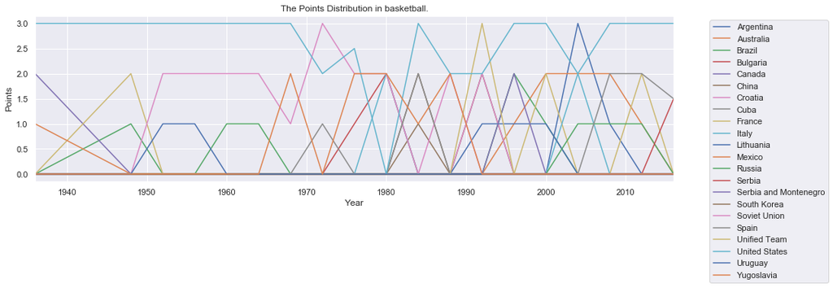

```python
winning_basketball = athlete_events[athlete_events['Sport'] == 'Basketball'].dropna(subset=['Medal'])
medal_mapping = {'Gold': 3, 'Silver': 2, 'Bronze': 1}
winning_basketball.loc[:, 'Medal'] = winning_basketball.loc[:, 'Medal'].map(medal_mapping)
winning_basketball = winning_basketball.groupby(['Year', 'Team'])['Medal'].mean().unstack().fillna(0)

sns.set(rc = {'figure.figsize':(15, 4)})
winning_basketball.plot()
plt.legend(bbox_to_anchor=(1.05, 1.0), loc='upper left')
plt.title('The Points Distribution in basketball.')
plt.ylabel('Points')
plt.show()
```

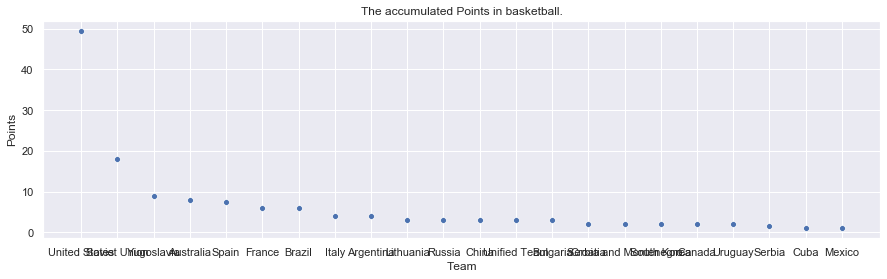

```python
country_ranking = winning_basketball.sum().reset_index(name ='Points').sort_values(by=['Points'], ascending=False)
sns.scatterplot(x='Team', y='Points', data=country_ranking)
plt.title('The accumulated Points in basketball.')
plt.show()
```

```python
top_three_country = country_ranking.head(3)
for i in range(3):
    print(i + 1, top_three_country['Team'].iloc[i], top_three_country['Points'].iloc[i], sep='\t')

# top_three_country.reset_index(drop=True, inplace=True)
# top_three_country.index += 1
# top_three_country
```

```
1	United States	49.5
2	Soviet Union	18.0
3	Yugoslavia	9.0
```

**Note:** There are 0.5 points appear because the games are split into playing with males and females.

**Reference:**

- drop Nan with specific columns: https://stackoverflow.com/questions/13413590/how-to-drop-rows-of-pandas-dataframe-whose-value-in-a-certain-column-is-nan
- fillna: https://pandas.pydata.org/docs/reference/api/pandas.DataFrame.fillna.html
- sort_values: https://pandas.pydata.org/docs/reference/api/pandas.DataFrame.sort_values.html
- Group by Sum as new column name: https://stackoverflow.com/questions/45124992/group-by-sum-as-new-column-name
- selecting top n rows: https://stackoverflow.com/questions/41825978/sorting-columns-and-selecting-top-n-rows-in-each-group-pandas-dataframe
- seaborn figure size: https://www.delftstack.com/howto/seaborn/size-of-seaborn-plot/
- reset index: https://pandas.pydata.org/docs/reference/api/pandas.Series.reset_index.html
- change index: https://stackoverflow.com/questions/32249960/in-python-pandas-start-row-index-from-1-instead-of-zero-without-creating-additi
- Place Legend Outside the Plot in Matplotlib: https://www.delftstack.com/howto/matplotlib/how-to-place-legend-outside-of-the-plot-in-matplotlib/

## (ii) Which country gets the longest winning streak in baseball? That is, Which country wins the longest in a row with the top three in baseball?

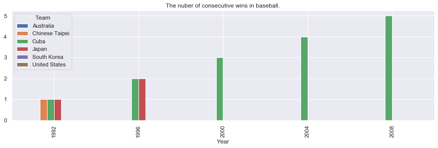

```python
winning_baseball = athlete_events[athlete_events['Sport'] == 'Baseball'].dropna(subset=['Medal'])
winning_baseball = winning_baseball.groupby(['Year', 'Team'])['Medal'].count().unstack().fillna(0)
winning_baseball[winning_baseball > 0] = 2

for row_id in range(len(winning_baseball.index) - 1):
    winning_baseball.iloc[row_id + 1, :] *= winning_baseball.iloc[row_id, :]
winning_baseball[winning_baseball == 0] = 1
winning_baseball = winning_baseball.transform(lambda x: np.log2(x))
winning_baseball.plot(kind='bar')
plt.title('The nuber of consecutive wins in baseball.')
```

```python
print(winning_baseball.max().idxmax(), 'wins the longest in a row with the top three in baseball.')
```

```
Cuba wins the longest in a row with the top three in baseball.
```

**Reference:**

- plot: https://pandas.pydata.org/docs/reference/api/pandas.DataFrame.plot.html

## (iii) What is the probability to get other medals when winning one medal?

```python
def n_win_team(df, games):
    if df.shape[0] == 0:
        print('No country win', games, 'at the same time.')
        return 0
    else:
        win_team = df.index.to_frame(index=False, name=['Year', 'Team'])
        n_team = win_team.shape[0]
        if n_team == 1:
            print('There is', n_team, 'country wins', games, 'at the same time.')
        elif n_team > 1:
            print('There are', n_team, 'countries win', games, 'at the same time.')
        print(win_team)
    print()
    return n_team
```

```python
pd.set_option('display.max_rows', None)
sports_list = ['Baseball', 'Basketball', 'Table Tennis']
winning_team = athlete_events[athlete_events['Sport'].isin(sports_list)].dropna(subset=['Medal'])
winning_team = winning_team.groupby(['Year', 'Team', 'Sport'])['Team'].count().unstack()

all_win = winning_team[(winning_team[sports_list[0]] > 0) & (winning_team[sports_list[1]] > 0)  & (winning_team[sports_list[2]] > 0)]

n_win_team(all_win, 'all three games')

win_baseball_basketball = winning_team[(winning_team[sports_list[0]] > 0) & (winning_team[sports_list[1]] > 0)]
win_baseball_tabletennis = winning_team[(winning_team[sports_list[0]] > 0) & (winning_team[sports_list[2]] > 0)]
win_basketball_tabletennis = winning_team[(winning_team[sports_list[1]] > 0) & (winning_team[sports_list[2]] > 0)]
n_win_baseball_basketball = n_win_team(win_baseball_basketball, 'the baseball and the basketball games')
n_win_baseball_tabletennis = n_win_team(win_baseball_tabletennis, 'the baseball and the table tennis games')
n_win_basketball_tabletennis = n_win_team(win_basketball_tabletennis, 'the basketball and the table tennis games')
```

```
No country win all three games at the same time.
There are 4 countries win the baseball and the basketball games at the same time.
   Year           Team
0  1996  United States
1  2000  United States
2  2004      Australia
3  2008  United States

There is 1 country wins the baseball and the table tennis games at the same time.
   Year         Team
0  2008  South Korea

There are 2 countries win the basketball and the table tennis games at the same time.
   Year        Team
0  1988  Yugoslavia
1  1992       China
```

```python
def print_sport_intro(sport):
    print('When the country wins a medal in {}.' .format(sport))

def print_chance_and_sport(chance, sport):
    print('It is about %.2f percent chance to earn another medal in %s.' % (chance * 100, sport))
```

```python
winning_baseball = winning_team[sports_list[0]].dropna()
n_win_baseball = winning_baseball.shape[0]
print_sport_intro(sports_list[0])
print_chance_and_sport(n_win_baseball_basketball / n_win_baseball, sports_list[1])
print_chance_and_sport(n_win_baseball_tabletennis / n_win_baseball, sports_list[2])
chance_baseball = (n_win_baseball_basketball + n_win_baseball_tabletennis) / n_win_baseball
print_chance_and_sport(chance_baseball, sports_list[1] + ' or ' + sports_list[2])
print()

winning_basketball = winning_team[sports_list[1]].dropna()
n_win_basketball = winning_basketball.shape[0]
print_sport_intro(sports_list[1])
print_chance_and_sport(n_win_baseball_basketball / n_win_basketball, sports_list[0])
print_chance_and_sport(n_win_basketball_tabletennis / n_win_basketball, sports_list[2])
chance_basketball = (n_win_baseball_basketball + n_win_basketball_tabletennis) / n_win_basketball
print_chance_and_sport(chance_basketball, sports_list[0] + ' or ' + sports_list[2])
print()

winning_tabletennis = winning_team[sports_list[2]].dropna()
n_win_tabletennis = winning_tabletennis.shape[0]
print_sport_intro(sports_list[2])
print_chance_and_sport(n_win_baseball_tabletennis / n_win_tabletennis, sports_list[0])
print_chance_and_sport(n_win_basketball_tabletennis / n_win_tabletennis, sports_list[1])
chance_tabletennis = (n_win_baseball_tabletennis + n_win_basketball_tabletennis) / n_win_tabletennis
print_chance_and_sport(chance_tabletennis, sports_list[0] + ' or ' + sports_list[1])
```

```
When the country wins a medal in Baseball.
It is about 26.67 percent chance to earn another medal in Basketball.
It is about 6.67 percent chance to earn another medal in Table Tennis.
It is about 33.33 percent chance to earn another medal in Basketball or Table Tennis.

When the country wins a medal in Basketball.
It is about 5.48 percent chance to earn another medal in Baseball.
It is about 2.74 percent chance to earn another medal in Table Tennis.
It is about 8.22 percent chance to earn another medal in Baseball or Table Tennis.

When the country wins a medal in Table Tennis.
It is about 1.92 percent chance to earn another medal in Baseball.
It is about 3.85 percent chance to earn another medal in Basketball.
It is about 5.77 percent chance to earn another medal in Baseball or Basketball.
```

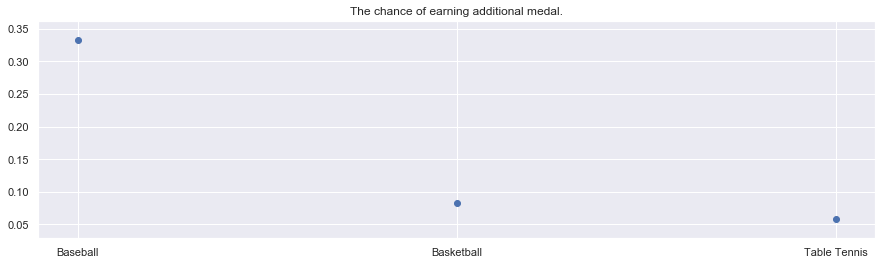

```python
chance = [chance_baseball, chance_basketball, chance_tabletennis]
plt.scatter(x=sports_list, y=chance)
plt.title('The chance of earning additional medal.')
```

It is the highest probability to earn another medal When winning a medal in Baseball among three sports games.

# (d) Submission instructions:

## i. Consolidate your answers to (a), (b), (c) above in a PDF file.

## ii. Put all your codes in a Python file that is runnable on its own. You can also submit in Jupyter format.

## iii. Put the datafiles in the same directory as your code.